# Risk Factor Analysis

## Outcome Variable

**Outcome Variable:** ever_wasted

## Predictor Variables

**Intervention Variable:** cleanck

**Adjustment Set:**

- arm
- sex
- W_mage
- meducyrs
- feducyrs
- hhwealth_quart
- W_nrooms
- W_nhh
- W_nchldlt5
- trth2o
- impfloor
- delta_meducyrs
- delta_feducyrs
- delta_hhwealth_quart
- delta_W_nrooms
- delta_W_nhh
- delta_W_nchldlt5
- delta_trth2o
- delta_impfloor

## Stratifying Variables

The analysis was stratified on these variable(s):

- agecat
- studyid
- country

## Data Summary

| agecat | studyid | country | cleanck | ever_wasted | n_cell | n |
| --- | --- | --- | --- | --- | --- | --- |
| 0-24 months (no birth wast) | CMC-V-BCS-2002 | INDIA | 1 | 0 | 104 | 368 |
| 0-24 months (no birth wast) | CMC-V-BCS-2002 | INDIA | 1 | 1 | 59 | 368 |
| 0-24 months (no birth wast) | CMC-V-BCS-2002 | INDIA | 0 | 0 | 98 | 368 |
| 0-24 months (no birth wast) | CMC-V-BCS-2002 | INDIA | 0 | 1 | 107 | 368 |
| 0-24 months (no birth wast) | GMS-Nepal | NEPAL | 1 | 0 | 7 | 589 |
| 0-24 months (no birth wast) | GMS-Nepal | NEPAL | 1 | 1 | 2 | 589 |
| 0-24 months (no birth wast) | GMS-Nepal | NEPAL | 0 | 0 | 279 | 589 |
| 0-24 months (no birth wast) | GMS-Nepal | NEPAL | 0 | 1 | 301 | 589 |
| 0-24 months (no birth wast) | IRC | INDIA | 1 | 0 | 107 | 399 |
| 0-24 months (no birth wast) | IRC | INDIA | 1 | 1 | 123 | 399 |
| 0-24 months (no birth wast) | IRC | INDIA | 0 | 0 | 84 | 399 |
| 0-24 months (no birth wast) | IRC | INDIA | 0 | 1 | 85 | 399 |
| 0-24 months (no birth wast) | MAL-ED | PERU | 1 | 0 | 1 | 2 |
| 0-24 months (no birth wast) | MAL-ED | PERU | 1 | 1 | 0 | 2 |
| 0-24 months (no birth wast) | MAL-ED | PERU | 0 | 0 | 1 | 2 |
| 0-24 months (no birth wast) | MAL-ED | PERU | 0 | 1 | 0 | 2 |
| 0-24 months (no birth wast) | MAL-ED | SOUTH AFRICA | 1 | 0 | 2 | 3 |
| 0-24 months (no birth wast) | MAL-ED | SOUTH AFRICA | 1 | 1 | 0 | 3 |
| 0-24 months (no birth wast) | MAL-ED | SOUTH AFRICA | 0 | 0 | 1 | 3 |
| 0-24 months (no birth wast) | MAL-ED | SOUTH AFRICA | 0 | 1 | 0 | 3 |
| 0-24 months (no birth wast) | NIH-Crypto | BANGLADESH | 1 | 0 | 319 | 575 |
| 0-24 months (no birth wast) | NIH-Crypto | BANGLADESH | 1 | 1 | 39 | 575 |
| 0-24 months (no birth wast) | NIH-Crypto | BANGLADESH | 0 | 0 | 181 | 575 |
| 0-24 months (no birth wast) | NIH-Crypto | BANGLADESH | 0 | 1 | 36 | 575 |
| 0-24 months (no birth wast) | PROVIDE | BANGLADESH | 1 | 0 | 471 | 687 |
| 0-24 months (no birth wast) | PROVIDE | BANGLADESH | 1 | 1 | 90 | 687 |
| 0-24 months (no birth wast) | PROVIDE | BANGLADESH | 0 | 0 | 94 | 687 |
| 0-24 months (no birth wast) | PROVIDE | BANGLADESH | 0 | 1 | 32 | 687 |
| 0-6 months (no birth wast) | CMC-V-BCS-2002 | INDIA | 1 | 0 | 117 | 350 |
| 0-6 months (no birth wast) | CMC-V-BCS-2002 | INDIA | 1 | 1 | 40 | 350 |
| 0-6 months (no birth wast) | CMC-V-BCS-2002 | INDIA | 0 | 0 | 125 | 350 |
| 0-6 months (no birth wast) | CMC-V-BCS-2002 | INDIA | 0 | 1 | 68 | 350 |
| 0-6 months (no birth wast) | GMS-Nepal | NEPAL | 1 | 0 | 7 | 576 |
| 0-6 months (no birth wast) | GMS-Nepal | NEPAL | 1 | 1 | 1 | 576 |
| 0-6 months (no birth wast) | GMS-Nepal | NEPAL | 0 | 0 | 456 | 576 |
| 0-6 months (no birth wast) | GMS-Nepal | NEPAL | 0 | 1 | 112 | 576 |
| 0-6 months (no birth wast) | IRC | INDIA | 1 | 0 | 136 | 381 |
| 0-6 months (no birth wast) | IRC | INDIA | 1 | 1 | 86 | 381 |
| 0-6 months (no birth wast) | IRC | INDIA | 0 | 0 | 115 | 381 |
| 0-6 months (no birth wast) | IRC | INDIA | 0 | 1 | 44 | 381 |
| 0-6 months (no birth wast) | MAL-ED | PERU | 1 | 0 | 1 | 2 |
| 0-6 months (no birth wast) | MAL-ED | PERU | 1 | 1 | 0 | 2 |
| 0-6 months (no birth wast) | MAL-ED | PERU | 0 | 0 | 1 | 2 |
| 0-6 months (no birth wast) | MAL-ED | PERU | 0 | 1 | 0 | 2 |
| 0-6 months (no birth wast) | MAL-ED | SOUTH AFRICA | 1 | 0 | 2 | 3 |
| 0-6 months (no birth wast) | MAL-ED | SOUTH AFRICA | 1 | 1 | 0 | 3 |
| 0-6 months (no birth wast) | MAL-ED | SOUTH AFRICA | 0 | 0 | 1 | 3 |
| 0-6 months (no birth wast) | MAL-ED | SOUTH AFRICA | 0 | 1 | 0 | 3 |
| 0-6 months (no birth wast) | NIH-Crypto | BANGLADESH | 1 | 0 | 351 | 572 |
| 0-6 months (no birth wast) | NIH-Crypto | BANGLADESH | 1 | 1 | 4 | 572 |
| 0-6 months (no birth wast) | NIH-Crypto | BANGLADESH | 0 | 0 | 208 | 572 |
| 0-6 months (no birth wast) | NIH-Crypto | BANGLADESH | 0 | 1 | 9 | 572 |
| 0-6 months (no birth wast) | PROVIDE | BANGLADESH | 1 | 0 | 530 | 683 |
| 0-6 months (no birth wast) | PROVIDE | BANGLADESH | 1 | 1 | 27 | 683 |
| 0-6 months (no birth wast) | PROVIDE | BANGLADESH | 0 | 0 | 116 | 683 |
| 0-6 months (no birth wast) | PROVIDE | BANGLADESH | 0 | 1 | 10 | 683 |
| 6-24 months | CMC-V-BCS-2002 | INDIA | 1 | 0 | 128 | 373 |
| 6-24 months | CMC-V-BCS-2002 | INDIA | 1 | 1 | 35 | 373 |
| 6-24 months | CMC-V-BCS-2002 | INDIA | 0 | 0 | 146 | 373 |
| 6-24 months | CMC-V-BCS-2002 | INDIA | 0 | 1 | 64 | 373 |
| 6-24 months | GMS-Nepal | NEPAL | 1 | 0 | 6 | 529 |
| 6-24 months | GMS-Nepal | NEPAL | 1 | 1 | 2 | 529 |
| 6-24 months | GMS-Nepal | NEPAL | 0 | 0 | 269 | 529 |
| 6-24 months | GMS-Nepal | NEPAL | 0 | 1 | 252 | 529 |
| 6-24 months | IRC | INDIA | 1 | 0 | 166 | 400 |
| 6-24 months | IRC | INDIA | 1 | 1 | 65 | 400 |
| 6-24 months | IRC | INDIA | 0 | 0 | 110 | 400 |
| 6-24 months | IRC | INDIA | 0 | 1 | 59 | 400 |
| 6-24 months | MAL-ED | SOUTH AFRICA | 1 | 0 | 1 | 1 |
| 6-24 months | MAL-ED | SOUTH AFRICA | 1 | 1 | 0 | 1 |
| 6-24 months | MAL-ED | SOUTH AFRICA | 0 | 0 | 0 | 1 |
| 6-24 months | MAL-ED | SOUTH AFRICA | 0 | 1 | 0 | 1 |
| 6-24 months | NIH-Crypto | BANGLADESH | 1 | 0 | 306 | 559 |
| 6-24 months | NIH-Crypto | BANGLADESH | 1 | 1 | 37 | 559 |
| 6-24 months | NIH-Crypto | BANGLADESH | 0 | 0 | 186 | 559 |
| 6-24 months | NIH-Crypto | BANGLADESH | 0 | 1 | 30 | 559 |
| 6-24 months | PROVIDE | BANGLADESH | 1 | 0 | 437 | 615 |
| 6-24 months | PROVIDE | BANGLADESH | 1 | 1 | 71 | 615 |
| 6-24 months | PROVIDE | BANGLADESH | 0 | 0 | 79 | 615 |
| 6-24 months | PROVIDE | BANGLADESH | 0 | 1 | 28 | 615 |

The following strata were considered:

- agecat: 0-24 months (no birth wast), studyid: CMC-V-BCS-2002, country: INDIA
- agecat: 0-24 months (no birth wast), studyid: GMS-Nepal, country: NEPAL
- agecat: 0-24 months (no birth wast), studyid: IRC, country: INDIA
- agecat: 0-24 months (no birth wast), studyid: MAL-ED, country: PERU
- agecat: 0-24 months (no birth wast), studyid: MAL-ED, country: SOUTH AFRICA
- agecat: 0-24 months (no birth wast), studyid: NIH-Crypto, country: BANGLADESH
- agecat: 0-24 months (no birth wast), studyid: PROVIDE, country: BANGLADESH
- agecat: 0-6 months (no birth wast), studyid: CMC-V-BCS-2002, country: INDIA
- agecat: 0-6 months (no birth wast), studyid: GMS-Nepal, country: NEPAL
- agecat: 0-6 months (no birth wast), studyid: IRC, country: INDIA
- agecat: 0-6 months (no birth wast), studyid: MAL-ED, country: PERU
- agecat: 0-6 months (no birth wast), studyid: MAL-ED, country: SOUTH AFRICA
- agecat: 0-6 months (no birth wast), studyid: NIH-Crypto, country: BANGLADESH
- agecat: 0-6 months (no birth wast), studyid: PROVIDE, country: BANGLADESH
- agecat: 6-24 months, studyid: CMC-V-BCS-2002, country: INDIA
- agecat: 6-24 months, studyid: GMS-Nepal, country: NEPAL
- agecat: 6-24 months, studyid: IRC, country: INDIA
- agecat: 6-24 months, studyid: MAL-ED, country: SOUTH AFRICA
- agecat: 6-24 months, studyid: NIH-Crypto, country: BANGLADESH
- agecat: 6-24 months, studyid: PROVIDE, country: BANGLADESH

### Dropped Strata

Some strata were dropped due to rare outcomes:

- agecat: 0-24 months (no birth wast), studyid: GMS-Nepal, country: NEPAL
- agecat: 0-24 months (no birth wast), studyid: MAL-ED, country: PERU
- agecat: 0-24 months (no birth wast), studyid: MAL-ED, country: SOUTH AFRICA
- agecat: 0-6 months (no birth wast), studyid: GMS-Nepal, country: NEPAL
- agecat: 0-6 months (no birth wast), studyid: MAL-ED, country: PERU
- agecat: 0-6 months (no birth wast), studyid: MAL-ED, country: SOUTH AFRICA
- agecat: 0-6 months (no birth wast), studyid: NIH-Crypto, country: BANGLADESH
- agecat: 6-24 months, studyid: GMS-Nepal, country: NEPAL
- agecat: 6-24 months, studyid: MAL-ED, country: SOUTH AFRICA

## Methods Detail

We’re interested in the causal parameters $E[Y_a]$ for all values of $a \in \mathcal{A}$. These parameters represent the mean outcome if, possibly contrary to fact, we intervened to set all units to have $A=a$. Under the randomization and positivity assumptions, these are identified by the statistical parameters $\psi_a=E_W[E_{Y|A,W}(Y|A=a,W)]$. In addition, we’re interested in the mean of $Y$, $E[Y]$ under no intervention (the observed mean). We will estimate these parameters by using SuperLearner to fit the relevant likelihood factors – $E_{Y|A,W}(Y|A=a,W)$ and $p(A=a|W)$, and then updating our likelihood fit using a joint TMLE.

For unadjusted analyses ($W=\{\}$), initial likelihoods were estimated using Lrnr_glm to estimate the simple $E(Y|A)$ and Lrnr_mean to estimate $p(A)$. For adjusted analyses, a small library containing Lrnr_glmnet, Lrnr_xgboost, and Lrnr_mean was used.

Having estimated these parameters, we will then use the delta method to estimate relative risks and attributable risks relative to a prespecified baseline level of $A$.

# Results Detail

## Results Plots

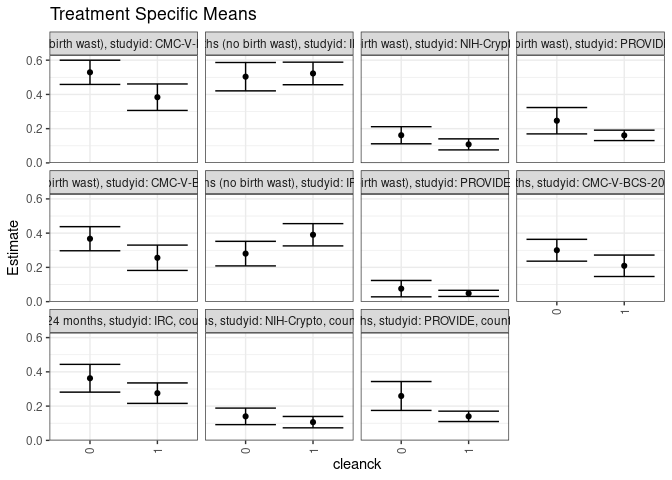

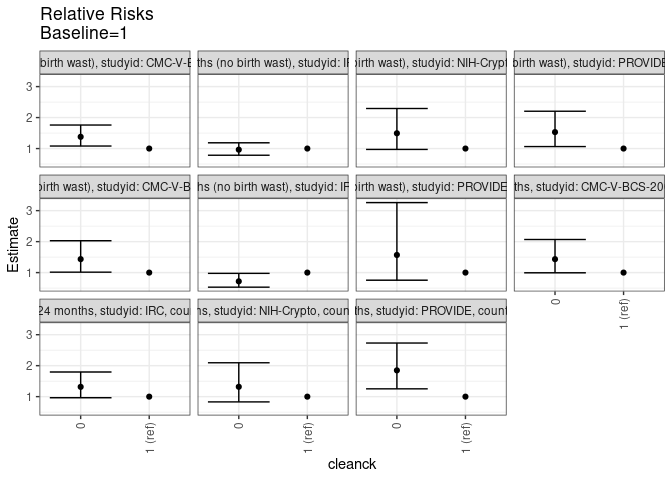

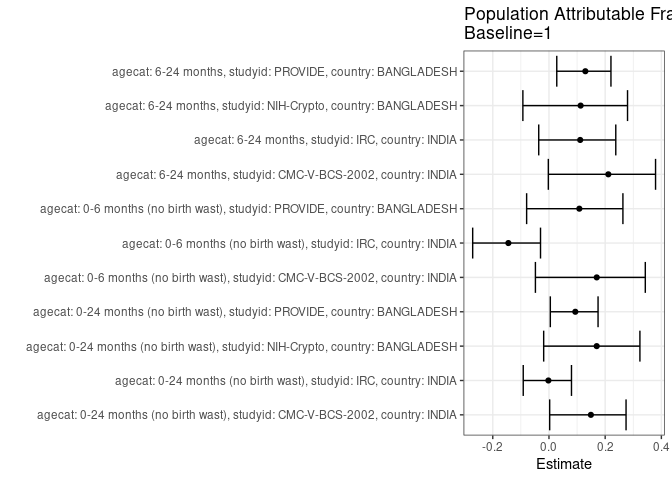

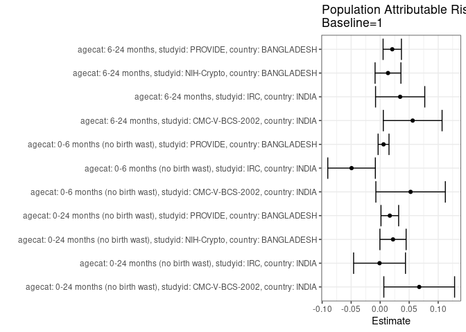

## Results Table

### Parameter: TSM

| agecat | studyid | country | intervention_level | baseline_level | estimate | ci_lower | ci_upper |
| --- | --- | --- | --- | --- | --- | --- | --- |
| 0-24 months (no birth wast) | CMC-V-BCS-2002 | INDIA | 1 | NA | 0.3837871 | 0.3064563 | 0.4611179 |
| 0-24 months (no birth wast) | CMC-V-BCS-2002 | INDIA | 0 | NA | 0.5290496 | 0.4582937 | 0.5998056 |
| 0-24 months (no birth wast) | IRC | INDIA | 1 | NA | 0.5223740 | 0.4565682 | 0.5881798 |
| 0-24 months (no birth wast) | IRC | INDIA | 0 | NA | 0.5035986 | 0.4207634 | 0.5864338 |
| 0-24 months (no birth wast) | NIH-Crypto | BANGLADESH | 1 | NA | 0.1082778 | 0.0761177 | 0.1404378 |
| 0-24 months (no birth wast) | NIH-Crypto | BANGLADESH | 0 | NA | 0.1616411 | 0.1117057 | 0.2115765 |
| 0-24 months (no birth wast) | PROVIDE | BANGLADESH | 1 | NA | 0.1609416 | 0.1305329 | 0.1913503 |
| 0-24 months (no birth wast) | PROVIDE | BANGLADESH | 0 | NA | 0.2464313 | 0.1694846 | 0.3233779 |
| 0-6 months (no birth wast) | CMC-V-BCS-2002 | INDIA | 1 | NA | 0.2561166 | 0.1820986 | 0.3301345 |
| 0-6 months (no birth wast) | CMC-V-BCS-2002 | INDIA | 0 | NA | 0.3673368 | 0.2969362 | 0.4377375 |
| 0-6 months (no birth wast) | IRC | INDIA | 1 | NA | 0.3904895 | 0.3255718 | 0.4554072 |
| 0-6 months (no birth wast) | IRC | INDIA | 0 | NA | 0.2804479 | 0.2087046 | 0.3521911 |
| 0-6 months (no birth wast) | PROVIDE | BANGLADESH | 1 | NA | 0.0483150 | 0.0304650 | 0.0661649 |
| 0-6 months (no birth wast) | PROVIDE | BANGLADESH | 0 | NA | 0.0757917 | 0.0279625 | 0.1236210 |
| 6-24 months | CMC-V-BCS-2002 | INDIA | 1 | NA | 0.2093463 | 0.1467494 | 0.2719432 |
| 6-24 months | CMC-V-BCS-2002 | INDIA | 0 | NA | 0.3001199 | 0.2364350 | 0.3638048 |
| 6-24 months | IRC | INDIA | 1 | NA | 0.2755410 | 0.2157794 | 0.3353026 |
| 6-24 months | IRC | INDIA | 0 | NA | 0.3626513 | 0.2816079 | 0.4436947 |
| 6-24 months | NIH-Crypto | BANGLADESH | 1 | NA | 0.1063501 | 0.0732489 | 0.1394514 |
| 6-24 months | NIH-Crypto | BANGLADESH | 0 | NA | 0.1402131 | 0.0919378 | 0.1884885 |
| 6-24 months | PROVIDE | BANGLADESH | 1 | NA | 0.1401322 | 0.1099143 | 0.1703500 |
| 6-24 months | PROVIDE | BANGLADESH | 0 | NA | 0.2590814 | 0.1746777 | 0.3434852 |

### Parameter: E(Y)

| agecat | studyid | country | intervention_level | baseline_level | estimate | ci_lower | ci_upper |
| --- | --- | --- | --- | --- | --- | --- | --- |
| 0-24 months (no birth wast) | CMC-V-BCS-2002 | INDIA | NA | NA | 0.4510870 | 0.4001777 | 0.5019962 |
| 0-24 months (no birth wast) | IRC | INDIA | NA | NA | 0.5213033 | 0.4722258 | 0.5703807 |
| 0-24 months (no birth wast) | NIH-Crypto | BANGLADESH | NA | NA | 0.1304348 | 0.1028836 | 0.1579859 |
| 0-24 months (no birth wast) | PROVIDE | BANGLADESH | NA | NA | 0.1775837 | 0.1489858 | 0.2061816 |
| 0-6 months (no birth wast) | CMC-V-BCS-2002 | INDIA | NA | NA | 0.3085714 | 0.2601110 | 0.3570318 |
| 0-6 months (no birth wast) | IRC | INDIA | NA | NA | 0.3412073 | 0.2935379 | 0.3888768 |
| 0-6 months (no birth wast) | PROVIDE | BANGLADESH | NA | NA | 0.0541728 | 0.0371844 | 0.0711612 |
| 6-24 months | CMC-V-BCS-2002 | INDIA | NA | NA | 0.2654155 | 0.2205451 | 0.3102860 |
| 6-24 months | IRC | INDIA | NA | NA | 0.3100000 | 0.2646197 | 0.3553803 |
| 6-24 months | NIH-Crypto | BANGLADESH | NA | NA | 0.1198569 | 0.0929081 | 0.1468057 |
| 6-24 months | PROVIDE | BANGLADESH | NA | NA | 0.1609756 | 0.1319065 | 0.1900447 |

### Parameter: RR

| agecat | studyid | country | intervention_level | baseline_level | estimate | ci_lower | ci_upper |
| --- | --- | --- | --- | --- | --- | --- | --- |
| 0-24 months (no birth wast) | CMC-V-BCS-2002 | INDIA | 1 | 1 | 1.0000000 | 1.0000000 | 1.0000000 |
| 0-24 months (no birth wast) | CMC-V-BCS-2002 | INDIA | 0 | 1 | 1.3784976 | 1.0806434 | 1.7584484 |
| 0-24 months (no birth wast) | IRC | INDIA | 1 | 1 | 1.0000000 | 1.0000000 | 1.0000000 |
| 0-24 months (no birth wast) | IRC | INDIA | 0 | 1 | 0.9640576 | 0.7836696 | 1.1859680 |
| 0-24 months (no birth wast) | NIH-Crypto | BANGLADESH | 1 | 1 | 1.0000000 | 1.0000000 | 1.0000000 |
| 0-24 months (no birth wast) | NIH-Crypto | BANGLADESH | 0 | 1 | 1.4928374 | 0.9718304 | 2.2931609 |
| 0-24 months (no birth wast) | PROVIDE | BANGLADESH | 1 | 1 | 1.0000000 | 1.0000000 | 1.0000000 |
| 0-24 months (no birth wast) | PROVIDE | BANGLADESH | 0 | 1 | 1.5311844 | 1.0633716 | 2.2048039 |
| 0-6 months (no birth wast) | CMC-V-BCS-2002 | INDIA | 1 | 1 | 1.0000000 | 1.0000000 | 1.0000000 |
| 0-6 months (no birth wast) | CMC-V-BCS-2002 | INDIA | 0 | 1 | 1.4342565 | 1.0140826 | 2.0285248 |
| 0-6 months (no birth wast) | IRC | INDIA | 1 | 1 | 1.0000000 | 1.0000000 | 1.0000000 |
| 0-6 months (no birth wast) | IRC | INDIA | 0 | 1 | 0.7181957 | 0.5291937 | 0.9746998 |
| 0-6 months (no birth wast) | PROVIDE | BANGLADESH | 1 | 1 | 1.0000000 | 1.0000000 | 1.0000000 |
| 0-6 months (no birth wast) | PROVIDE | BANGLADESH | 0 | 1 | 1.5687006 | 0.7548806 | 3.2598817 |
| 6-24 months | CMC-V-BCS-2002 | INDIA | 1 | 1 | 1.0000000 | 1.0000000 | 1.0000000 |
| 6-24 months | CMC-V-BCS-2002 | INDIA | 0 | 1 | 1.4336050 | 0.9936491 | 2.0683593 |
| 6-24 months | IRC | INDIA | 1 | 1 | 1.0000000 | 1.0000000 | 1.0000000 |
| 6-24 months | IRC | INDIA | 0 | 1 | 1.3161430 | 0.9647734 | 1.7954812 |
| 6-24 months | NIH-Crypto | BANGLADESH | 1 | 1 | 1.0000000 | 1.0000000 | 1.0000000 |
| 6-24 months | NIH-Crypto | BANGLADESH | 0 | 1 | 1.3184106 | 0.8299974 | 2.0942315 |
| 6-24 months | PROVIDE | BANGLADESH | 1 | 1 | 1.0000000 | 1.0000000 | 1.0000000 |
| 6-24 months | PROVIDE | BANGLADESH | 0 | 1 | 1.8488362 | 1.2517980 | 2.7306286 |

### Parameter: PAR

| agecat | studyid | country | intervention_level | baseline_level | estimate | ci_lower | ci_upper |
| --- | --- | --- | --- | --- | --- | --- | --- |
| 0-24 months (no birth wast) | CMC-V-BCS-2002 | INDIA | 1 | NA | 0.0672998 | 0.0063289 | 0.1282707 |
| 0-24 months (no birth wast) | IRC | INDIA | 1 | NA | -0.0010707 | -0.0457640 | 0.0436226 |
| 0-24 months (no birth wast) | NIH-Crypto | BANGLADESH | 1 | NA | 0.0221570 | -0.0004227 | 0.0447367 |
| 0-24 months (no birth wast) | PROVIDE | BANGLADESH | 1 | NA | 0.0166421 | 0.0014325 | 0.0318517 |
| 0-6 months (no birth wast) | CMC-V-BCS-2002 | INDIA | 1 | NA | 0.0524549 | -0.0074084 | 0.1123181 |
| 0-6 months (no birth wast) | IRC | INDIA | 1 | NA | -0.0492821 | -0.0902724 | -0.0082919 |
| 0-6 months (no birth wast) | PROVIDE | BANGLADESH | 1 | NA | 0.0058578 | -0.0035218 | 0.0152374 |
| 6-24 months | CMC-V-BCS-2002 | INDIA | 1 | NA | 0.0560692 | 0.0054261 | 0.1067124 |
| 6-24 months | IRC | INDIA | 1 | NA | 0.0344590 | -0.0079487 | 0.0768667 |
| 6-24 months | NIH-Crypto | BANGLADESH | 1 | NA | 0.0135068 | -0.0087644 | 0.0357779 |
| 6-24 months | PROVIDE | BANGLADESH | 1 | NA | 0.0208434 | 0.0050590 | 0.0366278 |

### Parameter: PAF

| agecat | studyid | country | intervention_level | baseline_level | estimate | ci_lower | ci_upper |
| --- | --- | --- | --- | --- | --- | --- | --- |
| 0-24 months (no birth wast) | CMC-V-BCS-2002 | INDIA | 1 | NA | 0.1491948 | 0.0025192 | 0.2743023 |
| 0-24 months (no birth wast) | IRC | INDIA | 1 | NA | -0.0020539 | -0.0915661 | 0.0801180 |
| 0-24 months (no birth wast) | NIH-Crypto | BANGLADESH | 1 | NA | 0.1698703 | -0.0188321 | 0.3236223 |
| 0-24 months (no birth wast) | PROVIDE | BANGLADESH | 1 | NA | 0.0937142 | 0.0048051 | 0.1746802 |
| 0-6 months (no birth wast) | CMC-V-BCS-2002 | INDIA | 1 | NA | 0.1699926 | -0.0482407 | 0.3427919 |
| 0-6 months (no birth wast) | IRC | INDIA | 1 | NA | -0.1444346 | -0.2714801 | -0.0300833 |
| 0-6 months (no birth wast) | PROVIDE | BANGLADESH | 1 | NA | 0.1081319 | -0.0794801 | 0.2631372 |
| 6-24 months | CMC-V-BCS-2002 | INDIA | 1 | NA | 0.2112508 | -0.0022598 | 0.3792774 |
| 6-24 months | IRC | INDIA | 1 | NA | 0.1111581 | -0.0364462 | 0.2377415 |
| 6-24 months | NIH-Crypto | BANGLADESH | 1 | NA | 0.1126908 | -0.0928459 | 0.2795713 |
| 6-24 months | PROVIDE | BANGLADESH | 1 | NA | 0.1294820 | 0.0277515 | 0.2205680 |